# Fit GAMs to dispersal patterns of *Ascochyta* conidia

A.H. Sparks

2020-02-25

## 0.1 Import Data

See “R/wrangle_raw_data.R” for the script that handles the data import. This Rmd file focuses on the models themselves.

## 0.2 Fit GAMs

For reproducibility purposes, use `set.seed()`.

```r
set.seed(27)
```

### 0.2.1 mod1 - s(Distance)

```
##
## Family: gaussian
## Link function: identity
##
## Formula:
## mean_count_pot ~ s(dist, k = 5)
##
## Parametric coefficients:
##             Estimate Std. Error t value Pr(>|t|)
## (Intercept)  1.08024    0.04751   22.74   <2e-16 ***
## ---
## Signif. codes:  0 '***' 0.001 '**' 0.01 '*' 0.05 '.' 0.1 ' ' 1
##
## Approximate significance of smooth terms:
##           edf Ref.df    F p-value
## s(dist) 3.926  3.996 78.4  <2e-16 ***
## ---
## Signif. codes:  0 '***' 0.001 '**' 0.01 '*' 0.05 '.' 0.1 ' ' 1
##
## R-sq.(adj) =  0.482   Deviance explained = 48.8%
## GCV = 0.76522  Scale est. = 0.75394   n = 334
```

### 0.2.2 mod2 - s(Distance) + Precipitation

```
##
## Family: gaussian
## Link function: identity
##
## Formula:
## mean_count_pot ~ sum_rain + s(dist, k = 5)
##
## Parametric coefficients:
##             Estimate Std. Error t value Pr(>|t|)
## (Intercept) 0.816921   0.090724   9.004  < 2e-16 ***
## sum_rain    0.028779   0.008496   3.387 0.000792 ***
## ---
## Signif. codes:  0 '***' 0.001 '**' 0.01 '*' 0.05 '.' 0.1 ' ' 1
##
## Approximate significance of smooth terms:
##           edf Ref.df     F p-value
## s(dist) 3.928  3.996 80.95  <2e-16 ***
## ---
## Signif. codes:  0 '***' 0.001 '**' 0.01 '*' 0.05 '.' 0.1 ' ' 1
##
## R-sq.(adj) =  0.498   Deviance explained = 50.5%
## GCV = 0.74389  Scale est. = 0.73069   n = 334
```

### 0.2.3 mod3 - s(Distance) + Windspeed

```
##
## Family: gaussian
## Link function: identity
##
## Formula:
## mean_count_pot ~ mws + s(dist, k = 5)
##
## Parametric coefficients:
##             Estimate Std. Error t value Pr(>|t|)
## (Intercept)  0.64401    0.11825   5.446 1.01e-07 ***
## mws          0.12273    0.03059   4.012 7.47e-05 ***
## ---
## Signif. codes:  0 '***' 0.001 '**' 0.01 '*' 0.05 '.' 0.1 ' ' 1
##
## Approximate significance of smooth terms:
##           edf Ref.df     F p-value
## s(dist) 3.929  3.996 81.99  <2e-16 ***
## ---
## Signif. codes:  0 '***' 0.001 '**' 0.01 '*' 0.05 '.' 0.1 ' ' 1
##
## R-sq.(adj) =  0.504   Deviance explained = 51.2%
## GCV = 0.73389  Scale est. = 0.72086   n = 334
```

### 0.2.4 mod4 - s(Distance) + Windspeed + Precipitation

```
##
## Family: gaussian
## Link function: identity
##
## Formula:
## mean_count_pot ~ sum_rain + mws + s(dist, k = 5)
##
## Parametric coefficients:
##             Estimate Std. Error t value Pr(>|t|)
## (Intercept) 0.473449   0.131519   3.600 0.000368 ***
## sum_rain    0.024009   0.008457   2.839 0.004808 **
## mws         0.108916   0.030659   3.552 0.000438 ***
## ---
## Signif. codes:  0 '***' 0.001 '**' 0.01 '*' 0.05 '.' 0.1 ' ' 1
##
## Approximate significance of smooth terms:
##          edf Ref.df    F p-value
## s(dist) 3.93  3.996 83.8  <2e-16 ***
## ---
## Signif. codes:  0 '***' 0.001 '**' 0.01 '*' 0.05 '.' 0.1 ' ' 1
##
## R-sq.(adj) =  0.515   Deviance explained = 52.3%
## GCV = 0.72064  Scale est. = 0.70569   n = 334
```

### 0.2.5 mod5 - s(Distance + Windspeed) + Precipitation

```
##
## Family: gaussian
## Link function: identity
##
## Formula:
## mean_count_pot ~ sum_rain + s(dist + mws, k = 5)
##
## Parametric coefficients:
##             Estimate Std. Error t value Pr(>|t|)
## (Intercept) 0.816921   0.090724   9.004  < 2e-16 ***
## sum_rain    0.028779   0.008496   3.387 0.000792 ***
## ---
## Signif. codes:  0 '***' 0.001 '**' 0.01 '*' 0.05 '.' 0.1 ' ' 1
##
## Approximate significance of smooth terms:
##           edf Ref.df     F p-value
## s(dist) 3.928  3.996 80.95  <2e-16 ***
## ---
## Signif. codes:  0 '***' 0.001 '**' 0.01 '*' 0.05 '.' 0.1 ' ' 1
##
## R-sq.(adj) =  0.498   Deviance explained = 50.5%
## GCV = 0.74389  Scale est. = 0.73069   n = 334
```

### 0.2.6 mod6 - s(Distance) + s(Windspeed) + Precipitation

```
##
## Family: gaussian
## Link function: identity
##
## Formula:
## mean_count_pot ~ sum_rain + s(dist, k = 5) + s(mws, k = 5)
##
## Parametric coefficients:
##             Estimate Std. Error t value Pr(>|t|)
## (Intercept)  1.37885    0.16680   8.267 3.59e-15 ***
## sum_rain    -0.03264    0.01760  -1.854   0.0646 .
## ---
## Signif. codes:  0 '***' 0.001 '**' 0.01 '*' 0.05 '.' 0.1 ' ' 1
##
## Approximate significance of smooth terms:
##           edf Ref.df     F  p-value
## s(dist) 3.938  3.997 93.81  < 2e-16 ***
## s(mws)  3.928  3.996 13.56 2.09e-10 ***
## ---
## Signif. codes:  0 '***' 0.001 '**' 0.01 '*' 0.05 '.' 0.1 ' ' 1
##
## R-sq.(adj) =  0.566   Deviance explained = 57.8%
## GCV = 0.6497  Scale est. = 0.63051   n = 334
```

### 0.2.7 mod7 - s(Distance) + s(Windspeed)

```
##
## Family: gaussian
## Link function: identity
##
## Formula:
## mean_count_pot ~ s(dist, k = 5) + s(mws, k = 5)
##
## Parametric coefficients:
##             Estimate Std. Error t value Pr(>|t|)
## (Intercept)  1.08024    0.04366   24.74   <2e-16 ***
## ---
## Signif. codes:  0 '***' 0.001 '**' 0.01 '*' 0.05 '.' 0.1 ' ' 1
##
## Approximate significance of smooth terms:
##           edf Ref.df     F  p-value
## s(dist) 3.937  3.997 92.96  < 2e-16 ***
## s(mws)  3.917  3.995 16.04 6.03e-12 ***
## ---
## Signif. codes:  0 '***' 0.001 '**' 0.01 '*' 0.05 '.' 0.1 ' ' 1
##
## R-sq.(adj) =  0.562   Deviance explained = 57.3%
## GCV = 0.65392  Scale est. = 0.63659   n = 334
```

### 0.2.8 mod8 - s(Distance) + s(Windspeed) + s(Precipitation)

```
##
## Family: gaussian
## Link function: identity
##
## Formula:
## mean_count_pot ~ s(dist, k = 5) + s(mws, k = 5) + s(sum_rain,
##     k = 5)
##
## Parametric coefficients:
##             Estimate Std. Error t value Pr(>|t|)
## (Intercept)  1.08024    0.04345   24.86   <2e-16 ***
## ---
## Signif. codes:  0 '***' 0.001 '**' 0.01 '*' 0.05 '.' 0.1 ' ' 1
##
## Approximate significance of smooth terms:
##               edf Ref.df      F p-value
## s(dist)     3.938  3.997 93.805  <2e-16 ***
## s(mws)      1.655  1.748  1.351  0.3360
## s(sum_rain) 3.203  3.232  3.278  0.0114 *
## ---
## Signif. codes:  0 '***' 0.001 '**' 0.01 '*' 0.05 '.' 0.1 ' ' 1
##
## R-sq.(adj) =  0.566   Deviance explained = 57.8%
## GCV = 0.64956  Scale est. = 0.63051   n = 334
```

### 0.2.9 mod9 - s(Distance) + s(Precipitation)

```
##
## Family: gaussian
## Link function: identity
##
## Formula:
## mean_count_pot ~ s(dist, k = 5) + s(sum_rain, k = 5)
##
## Parametric coefficients:
##             Estimate Std. Error t value Pr(>|t|)
## (Intercept)  1.08024    0.04393   24.59   <2e-16 ***
## ---
## Signif. codes:  0 '***' 0.001 '**' 0.01 '*' 0.05 '.' 0.1 ' ' 1
##
## Approximate significance of smooth terms:
##               edf Ref.df     F  p-value
## s(dist)     3.936  3.997 91.78  < 2e-16 ***
## s(sum_rain) 3.890  3.989 15.22 5.69e-11 ***
## ---
## Signif. codes:  0 '***' 0.001 '**' 0.01 '*' 0.05 '.' 0.1 ' ' 1
##
## R-sq.(adj) =  0.557   Deviance explained = 56.7%
## GCV = 0.66193  Scale est. = 0.64444   n = 334
```

### 0.2.10 mod10 - s(Distance) +s(Precipitation) + Windspeed

```
##
## Family: gaussian
## Link function: identity
##
## Formula:
## mean_count_pot ~ s(dist, k = 5) + s(sum_rain, k = 5) + mws
##
## Parametric coefficients:
##             Estimate Std. Error t value Pr(>|t|)
## (Intercept)  -2.7406     1.4576  -1.880  0.06097 .
## mws           1.0750     0.4099   2.623  0.00914 **
## ---
## Signif. codes:  0 '***' 0.001 '**' 0.01 '*' 0.05 '.' 0.1 ' ' 1
##
## Approximate significance of smooth terms:
##               edf Ref.df     F  p-value
## s(dist)     3.937  3.997 93.79  < 2e-16 ***
## s(sum_rain) 3.813  3.965 11.28 8.12e-09 ***
## ---
## Signif. codes:  0 '***' 0.001 '**' 0.01 '*' 0.05 '.' 0.1 ' ' 1
##
## R-sq.(adj) =  0.566   Deviance explained = 57.8%
## GCV = 0.64959  Scale est. = 0.63062   n = 334
```

### 0.2.11 mod11 - s(Distance) + s(Windspeed) + s(Precipitation), family = tw()

```
##
## Family: Tweedie(p=1.044)
## Link function: log
##
## Formula:
## mean_count_pot ~ s(dist, k = 5) + s(mws, k = 5) + s(sum_rain,
##     k = 5)
##
## Parametric coefficients:
##             Estimate Std. Error t value Pr(>|t|)
## (Intercept) -0.22821    0.04098  -5.569 5.39e-08 ***
## ---
## Signif. codes:  0 '***' 0.001 '**' 0.01 '*' 0.05 '.' 0.1 ' ' 1
##
## Approximate significance of smooth terms:
##               edf Ref.df       F p-value
## s(dist)     3.496  3.855 123.776  <2e-16 ***
## s(mws)      1.980  2.079   0.772   0.487
## s(sum_rain) 2.830  2.894   5.509   0.002 **
## ---
## Signif. codes:  0 '***' 0.001 '**' 0.01 '*' 0.05 '.' 0.1 ' ' 1
##
## R-sq.(adj) =  0.674   Deviance explained = 61.2%
## -REML = 310.11  Scale est. = 0.36397   n = 334
```

### 0.2.12 mod12 - s(Distance) + s(Precipitation) + Windspeed, family = tw()

```
##
## Family: Tweedie(p=1.044)
## Link function: log
##
## Formula:
## mean_count_pot ~ s(dist, k = 5) + s(sum_rain, k = 5) + mws
##
## Parametric coefficients:
##             Estimate Std. Error t value Pr(>|t|)
## (Intercept) -0.45815    0.09542  -4.801 2.41e-06 ***
## mws          0.06588    0.02373   2.776  0.00582 **
## ---
## Signif. codes:  0 '***' 0.001 '**' 0.01 '*' 0.05 '.' 0.1 ' ' 1
##
## Approximate significance of smooth terms:
##               edf Ref.df      F  p-value
## s(dist)     3.496  3.854 123.47  < 2e-16 ***
## s(sum_rain) 2.907  2.996  19.44 1.04e-11 ***
## ---
## Signif. codes:  0 '***' 0.001 '**' 0.01 '*' 0.05 '.' 0.1 ' ' 1
##
## R-sq.(adj) =  0.661   Deviance explained = 60.2%
## -REML = 312.88  Scale est. = 0.36493   n = 334
```

Looking at `mod11`, `mws` is not significant as a smoothed term, and we’d suspect it was linear anyway, so add it as a linear term only.

## 0.3 Compare the Models

### 0.3.1 AIC, BIC

```
## # A tibble: 12 x 7
##    model    df logLik   AIC   BIC deviance df.residual
##    <chr> <dbl>  <dbl> <dbl> <dbl>    <dbl>       <dbl>
##  1 mod11  9.31  -320.  663.  709.     141.        325.
##  2 mod12  8.40  -332.  686.  728.     144.        326.
##  3 mod8   9.80  -392.  805.  847.     204.        324.
##  4 mod10  9.75  -392.  805.  846.     204.        324.
##  5 mod6   9.87  -392.  806.  847.     204.        324.
##  6 mod7   8.85  -394.  808.  845.     207.        325.
##  7 mod9   8.83  -396.  812.  849.     210.        325.
##  8 mod4   6.93  -412.  840.  871.     231.        327.
##  9 mod3   5.93  -416.  846.  873.     236.        328.
## 10 mod2   5.93  -419.  851.  877.     240.        328.
## 11 mod5   5.93  -419.  851.  877.     240.        328.
## 12 mod1   4.93  -424.  860.  883.     248.        329.
```

### 0.3.2 R<sup>2</sup>

```
## # A tibble: 12 x 2
##    name  value
##    <chr> <dbl>
##  1 mod11 0.674
##  2 mod12 0.661
##  3 mod8  0.566
##  4 mod6  0.566
##  5 mod10 0.566
##  6 mod7  0.562
##  7 mod9  0.557
##  8 mod4  0.515
##  9 mod3  0.504
## 10 mod2  0.498
## 11 mod5  0.498
## 12 mod1  0.482
```

### 0.3.3 Coefficients

```
##
## mod1
```

```
## (Intercept)   s(dist).1   s(dist).2   s(dist).3   s(dist).4
##    1.080240  -13.444330    7.368783   -1.254080   -2.291845
```

```
##
## mod2
```

```
##  (Intercept)     sum_rain    s(dist).1    s(dist).2    s(dist).3    s(dist).4
##   0.81692128   0.02877889 -13.40978000   7.33464779  -1.25209090  -2.29384111
```

```
##
## mod3
```

```
## (Intercept)         mws   s(dist).1   s(dist).2   s(dist).3   s(dist).4
##   0.6440143   0.1227341 -13.4868763   7.3983152  -1.2560432  -2.2949104
```

```
##
## mod4
```

```
##  (Intercept)     sum_rain          mws    s(dist).1    s(dist).2    s(dist).3
##   0.47344866   0.02400933   0.10891607 -13.45271077   7.36612892  -1.25413637
##    s(dist).4
##  -2.29619141
```

```
##
## mod5
```

```
##  (Intercept)     sum_rain    s(dist).1    s(dist).2    s(dist).3    s(dist).4
##   0.81692128   0.02877889 -13.40978000   7.33464779  -1.25209090  -2.29384111
```

```
##
## mod6
```

```
##  (Intercept)     sum_rain    s(dist).1    s(dist).2    s(dist).3    s(dist).4
##   1.37884978  -0.03263607 -13.52238405   7.40993482  -1.25717173  -2.30322423
##     s(mws).1     s(mws).2     s(mws).3     s(mws).4
##   0.99626476 -10.70707340   6.66914918   0.59636619
```

```
##
## mod7
```

```
## (Intercept)   s(dist).1   s(dist).2   s(dist).3   s(dist).4    s(mws).1
##   1.0802395 -13.4771686   7.3732417  -1.2548767  -2.3023128   0.8682278
##    s(mws).2    s(mws).3    s(mws).4
##  -6.5428897   3.8305035   0.6604538
```

```
##
## mod8
```

```
##   (Intercept)     s(dist).1     s(dist).2     s(dist).3     s(dist).4
##     1.0802395   -13.5231892     7.4108603    -1.2572233    -2.3031202
##      s(mws).1      s(mws).2      s(mws).3      s(mws).4 s(sum_rain).1
##     0.3909139    -0.7059823     1.4344954     0.8082756    19.7199870
## s(sum_rain).2 s(sum_rain).3 s(sum_rain).4
##   328.5020104  -102.4610960     1.3525266
```

```
##
## mod9
```

```
##   (Intercept)     s(dist).1     s(dist).2     s(dist).3     s(dist).4
##      1.080240    -13.505613      7.398727     -1.256415     -2.301825
## s(sum_rain).1 s(sum_rain).2 s(sum_rain).3 s(sum_rain).4
##     -7.708430   -109.360856     34.329152     -1.330657
```

```
##
## mod10
```

```
##   (Intercept)           mws     s(dist).1     s(dist).2     s(dist).3
##     -2.740619      1.075017    -13.510016      7.401753     -1.256617
##     s(dist).4 s(sum_rain).1 s(sum_rain).2 s(sum_rain).3 s(sum_rain).4
##     -2.302155     82.075300   1298.724127   -407.240141      8.651373
```

```
##
## mod11
```

```
##   (Intercept)     s(dist).1     s(dist).2     s(dist).3     s(dist).4
##    -0.2282130    -3.7637074     1.8984225    -0.5265088    -1.1208624
##      s(mws).1      s(mws).2      s(mws).3      s(mws).4 s(sum_rain).1
##     0.5077483    -1.0676679     1.5218322     0.4780137    -0.9317942
## s(sum_rain).2 s(sum_rain).3 s(sum_rain).4
##     5.0627315    -1.2859969    -0.9520154
```

```
##
## mod12
```

```
##   (Intercept)           mws     s(dist).1     s(dist).2     s(dist).3
##   -0.45814928    0.06587563   -3.76782363    1.90297824   -0.52681818
##     s(dist).4 s(sum_rain).1 s(sum_rain).2 s(sum_rain).3 s(sum_rain).4
##   -1.12066486   -0.46302990    4.76460329   -1.55284478   -0.53564456
```

### 0.3.4 ANOVA

```
## Analysis of Deviance Table
##
## Model  1: mean_count_pot ~ s(dist, k = 5)
## Model  2: mean_count_pot ~ sum_rain + s(dist, k = 5)
## Model  3: mean_count_pot ~ mws + s(dist, k = 5)
## Model  4: mean_count_pot ~ sum_rain + mws + s(dist, k = 5)
## Model  5: mean_count_pot ~ sum_rain + s(dist + mws, k = 5)
## Model  6: mean_count_pot ~ sum_rain + s(dist, k = 5) + s(mws, k = 5)
## Model  7: mean_count_pot ~ s(dist, k = 5) + s(mws, k = 5)
## Model  8: mean_count_pot ~ s(dist, k = 5) + s(mws, k = 5) + s(sum_rain,
##     k = 5)
## Model  9: mean_count_pot ~ s(dist, k = 5) + s(sum_rain, k = 5)
## Model 10: mean_count_pot ~ s(dist, k = 5) + s(sum_rain, k = 5) + mws
## Model 11: mean_count_pot ~ s(dist, k = 5) + s(mws, k = 5) + s(sum_rain,
##     k = 5)
## Model 12: mean_count_pot ~ s(dist, k = 5) + s(sum_rain, k = 5) + mws
##    Resid. Df Resid. Dev          Df Deviance          F    Pr(>F)
## 1     329.00     248.10
## 2     328.00     239.72  1.00019797     8.38    23.0239 2.443e-06 ***
## 3     328.00     236.49  0.00017108     3.22 51787.2571 2.104e-07 ***
## 4     327.00     230.81  1.00011438     5.69    15.6198 9.506e-05 ***
## 5     328.00     239.72 -1.00028547    -8.91    24.4745 1.209e-06 ***
## 6     324.01     204.37  3.99671315    35.35    24.3000 < 2.2e-16 ***
## 7     325.01     206.98 -1.00100428    -2.61     7.1723 0.0077645 **
## 8     324.02     204.41  0.98528685     2.57     7.1674 0.0080586 **
## 9     325.01     209.55 -0.99146246    -5.14    14.2473 0.0001994 ***
## 10    324.04     204.48  0.97643885     5.07    14.2777 0.0002125 ***
## 11    323.65     639.81  0.38652451  -435.32
## 12    324.70     664.47 -1.05141022   -24.66    64.4458 5.254e-15 ***
## ---
## Signif. codes:  0 '***' 0.001 '**' 0.01 '*' 0.05 '.' 0.1 ' ' 1
```

### 0.3.5 Visualise the Models

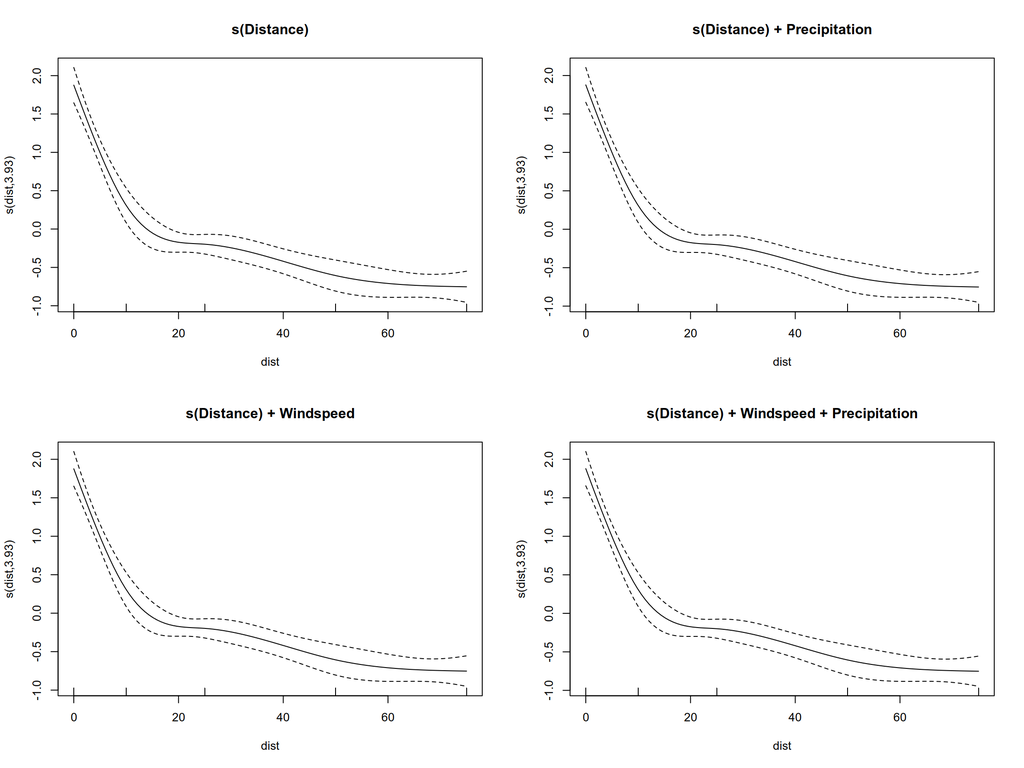

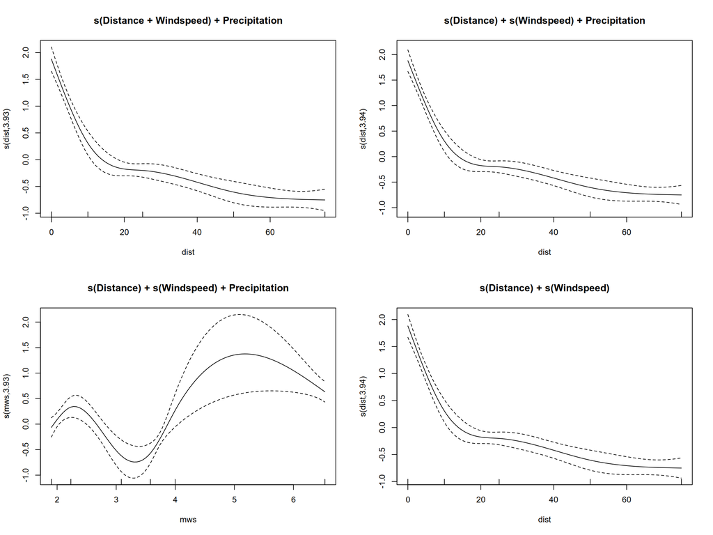

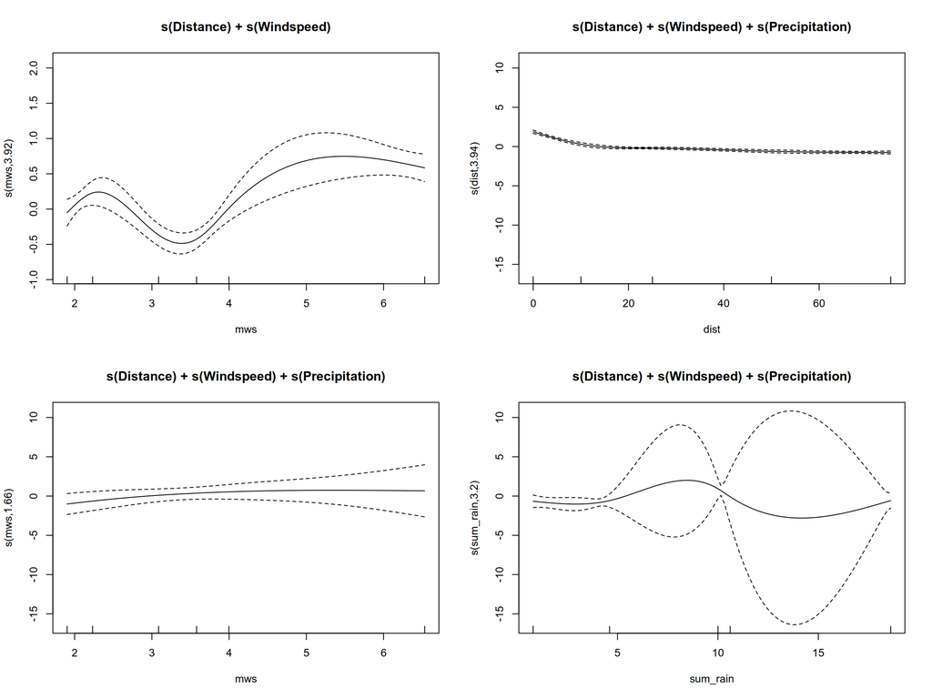

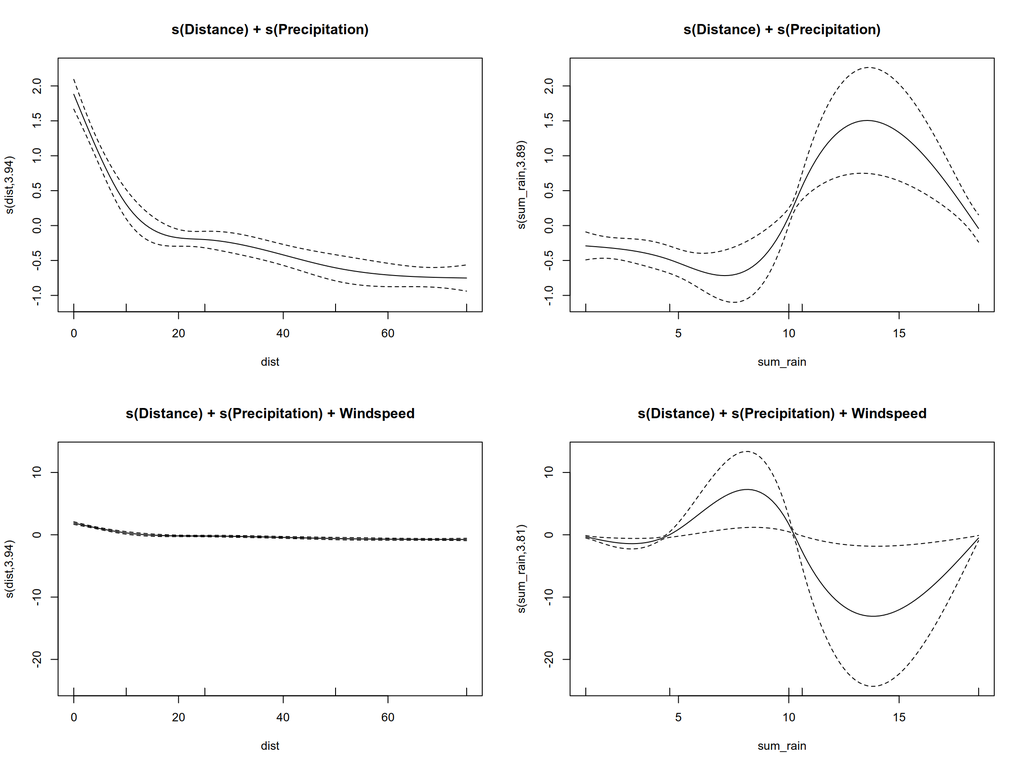

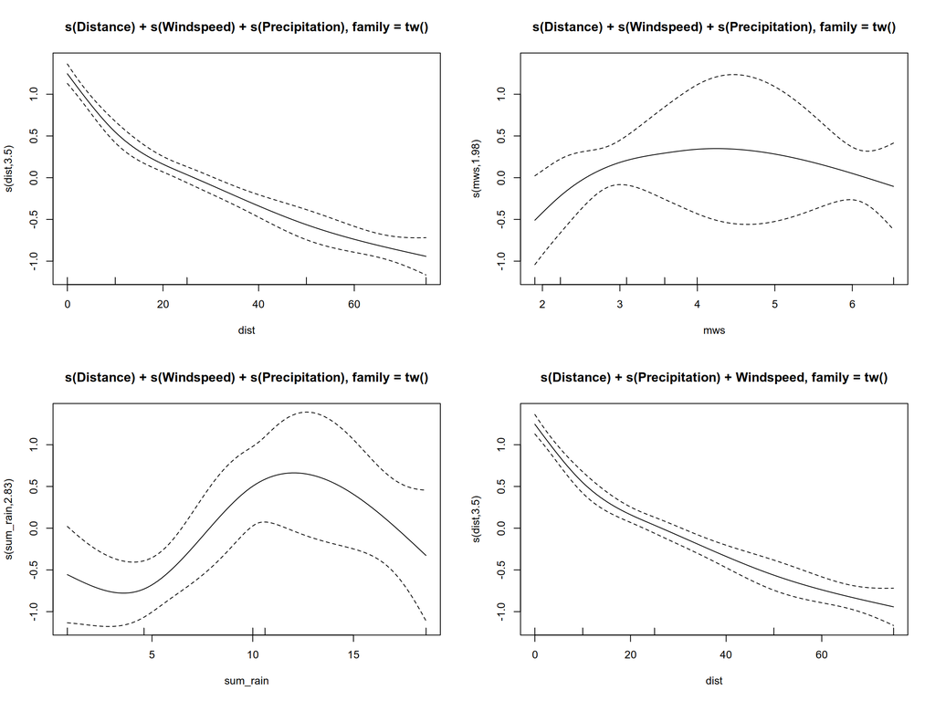

[figure not shown]

### 0.3.6 Check Best Model Fit

#### 0.3.6.1 Mod11 - s(Distance) + s(Windspeed) + s(Precipitation), family = tw()

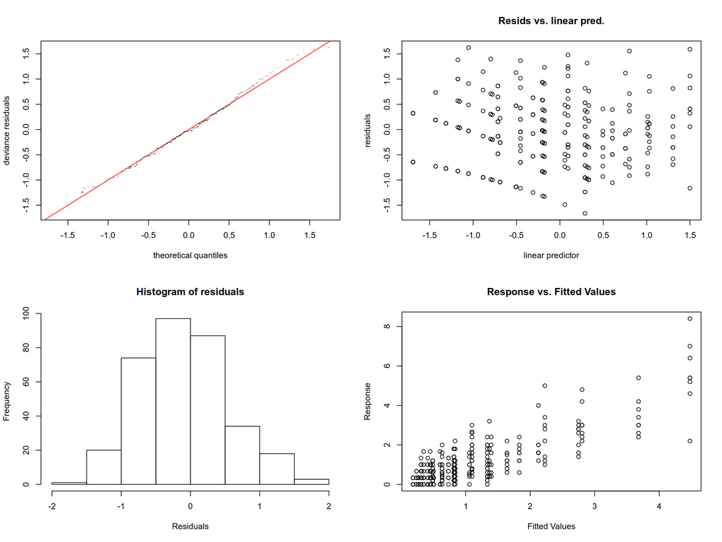

```
##
## Method: REML   Optimizer: outer newton
## full convergence after 9 iterations.
## Gradient range [-0.0002827365,-8.47808e-09]
## (score 310.1067 & scale 0.363966).
## Hessian positive definite, eigenvalue range [0.367564,2978.833].
## Model rank =  13 / 13
##
## Basis dimension (k) checking results. Low p-value (k-index<1) may
## indicate that k is too low, especially if edf is close to k'.
##
##               k'  edf k-index p-value
## s(dist)     4.00 3.50    0.86   0.010 **
## s(mws)      4.00 1.98    0.89   0.050 *
## s(sum_rain) 4.00 2.83    0.91   0.065 .
## ---
## Signif. codes:  0 '***' 0.001 '**' 0.01 '*' 0.05 '.' 0.1 ' ' 1
```

#### 0.3.6.2 Mod12 - s(Distance) + s(Precipitation) + Windspeed, family = tw()

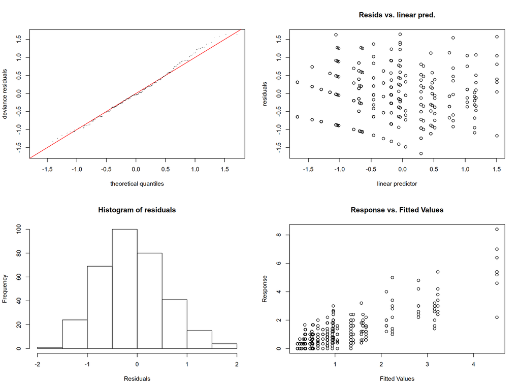

```
##
## Method: REML   Optimizer: outer newton
## full convergence after 8 iterations.
## Gradient range [-1.566137e-09,1.407417e-08]
## (score 312.8784 & scale 0.3649265).
## Hessian positive definite, eigenvalue range [0.7793274,2979.049].
## Model rank =  10 / 10
##
## Basis dimension (k) checking results. Low p-value (k-index<1) may
## indicate that k is too low, especially if edf is close to k'.
##
##               k'  edf k-index p-value
## s(dist)     4.00 3.50    0.83  <2e-16 ***
## s(sum_rain) 4.00 2.91    0.89   0.045 *
## ---
## Signif. codes:  0 '***' 0.001 '**' 0.01 '*' 0.05 '.' 0.1 ' ' 1
```

## 0.4 Thoughts

This model, `mean_pot_count ~ s(Distance) + s(Windspeed) + s(Precipitation) - family = tw()`, lacks enough numbers of basis functions for two of three predictors, `dist`, `wsp`, but it’s close. Realistically we need to increase the `k` values for these predictors, but we’re lacking the data to do this.